# Tutorial on the PTBoxProxytools package

2022-09-20

## Applications of package functions to example data

### Loading requirements

```r
library(PTBoxProxytools) # remove for public
library(PTBoxProxydata) # loads PTBoxProxydata dependency
library(magrittr) # for the %>% operator
```

### Applying functions to different `PTBoxProxydata` time series objects

First, we create a ProxyDataManager instance and load the `icecore_testset` built into PTBoxProxydata as data for testing the PTBoxProxytools functions. This outputs a `PTBoxProxydata::Proxytibble` object. This will be used to explain how to apply the package functions to it.

```r
mng <- ProxyDataManager()

icecore_data <- load_set(mng, dataset_names = 'icecore_testset', zoo_format = 'zoo') %>% clean_timeseries(.)
```

```
#> Loading datasets
#> icecore_testset
#> from RDS
```

```r
print(icecore_data)
```

```
#> # A data frame: 2 x 11
#>   dataset_id dataset_name entity_id entity_name site_archive   lat     lon  elev
#>        <dbl> <chr>            <dbl> <chr>       <chr>        <dbl>   <dbl> <dbl>
#> 1          4 edc_stenni           1 EPICA Dome… icecore      -74.9 1.23e+2 3216.
#> 2          5 edml_stenni          1 EPICA DML   icecore      -75.0 6.85e-2 2892
#> # … with 3 more variables: proxy_name <list>, proxy_data <list>,
#> #   proxy_unit <list>
```

> Please find also the `vignette("PTBoxProxydata_howto")` in the `PTBoxProxydata` package for an introduction to the data objects provided by `PTBoxProxydata`.

In a second step, we explore the basic usage for `PTBoxProxytools` functions that operate on proxy data. Therefore, we apply `PTBoxProxytools::paleodata_windowing` as an exemplary function to an individual time series (`zoo::zoo`)

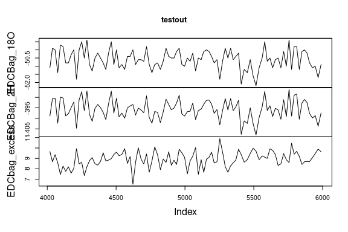

```r
# 1. example: apply `Proxytools` function (here `paleodata_windowing`)
# to an individual `zoo::zoo`
testout <- icecore_data$proxy_data[[1]] %>%
  paleodata_windowing(.,4000,6000)
plot(testout)
```

and to all time series stored in a Proxytibble (`PTBoxProxydata::Proxytibble`).

```r
# 2. example: apply function or to all `zoo::zoo`s/`PTBoxProxydata::Proxyzoo`s
# contained in a `PTBoxProxydata::Proxytibble`
testout <- icecore_data %>%
  paleodata_windowing(.,4000,6000)
print(testout)
```

```
#> # A data frame: 2 x 11
#>   dataset_id dataset_name entity_id entity_name site_archive   lat     lon  elev
#>        <dbl> <chr>            <dbl> <chr>       <chr>        <dbl>   <dbl> <dbl>
#> 1          4 edc_stenni           1 EPICA Dome… icecore      -74.9 1.23e+2 3216.
#> 2          5 edml_stenni          1 EPICA DML   icecore      -75.0 6.85e-2 2892
#> # … with 3 more variables: proxy_name <list>, proxy_data <list>,
#> #   proxy_unit <list>
```

### Some useful examples of `PTBoxProxytools` functions

#### 1. Normalization to center and rescale irregular time series

```r
# normalization
testout <- icecore_data$proxy_data[[1]] %>%
  normalize()
head(testout,3)
```

```
#>      EDCBag_18O EDCBag_2H EDCbag_excess
#> 46.8   1.663386  1.617702   -0.08493248
#> 55.1   2.135584  1.996741   -0.57693027
#> 64.4   1.148261  1.150393    0.21255456
```

#### 2. Interpolation for irregular time series

```r
# interpolation
# internally uses PTBoxProxydata::zoo_apply
some_window <- icecore_data$proxy_data[[1]] %>%
  zoo::index() %>%
  .[c(1,length(.))]
outtimes <- seq(some_window[1], some_window[2], length.out = 20)
testout <- icecore_data$proxy_data[[1]] %>%
  paleodata_interpolation(., "spectral", outtimes)
head(testout,3)
```

```
#>            EDCBag_18O EDCBag_2H EDCbag_excess
#> 46.8        -50.64550 -396.0386      9.075978
#> 7415.9158   -50.67669 -396.3065      9.067826
#> 14785.0316  -53.00998 -417.5295      6.520324
```

```r
print(dim(testout)[1])
```

[output not shown]

```r
# output is still a zoo
print(class(testout))
```

```
#> [1] "zoo"
```

#### 3. Gaussian filtering of irregular time series

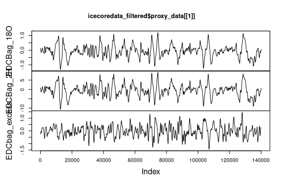

```r
# Detrend ice core data with 10kyr cutoff timescale
icecoredata_detrended <- paleodata_filtering(icecore_data, 'detrend', detr_scale=10000)
# Smooth the data with 10kyr cutoff timescale
icecoredata_smoothed <- paleodata_filtering(icecore_data, 'smooth', smooth_scale=10000)
# Apply bandpass filter for timescales from 1kyr to 10kyr
icecoredata_filtered <- paleodata_filtering(icecore_data, 'bandpass', filter_scales=data.frame(lower=1000,upper=10000))
# Plot results
#plot(icecoredata_detrended$proxy_data[[1]])
#plot(icecoredata_smoothed$proxy_data[[1]])
plot(icecoredata_filtered$proxy_data[[1]]) #we show only one example plot
```

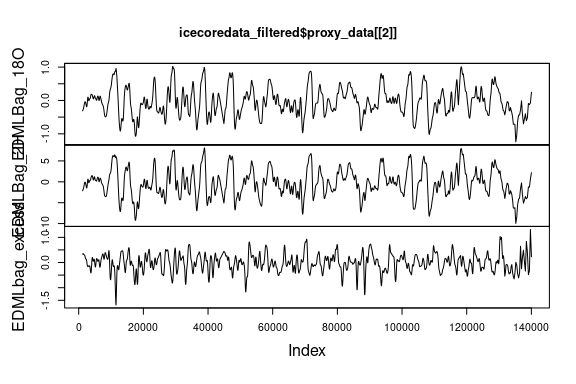

```r
plot(icecoredata_filtered$proxy_data[[2]]) #we show only one example plot
```

#### 4. Spectral analysis

First, we compute and plot the spectrum.

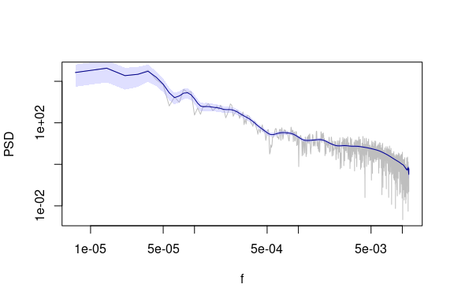

```r
testout <- icecore_data$proxy_data[[1]] %>%
  paleodata_spectrum(.)

library(PaleoSpec)
PaleoSpec::LPlot(testout$EDCBag_18O$raw, col="grey")
PaleoSpec::LLines(testout$EDCBag_18O$logsmooth, col="darkblue")
```

Second, we compute the variance on timescales of 200 to 2000 years, which is stored in the `proxy_data` column.

```r
testout <- icecore_data %>%
  paleodata_varfromspec(.,  target="raw", freq.start = 5e-4, freq.end = 5e-3)
head(testout$proxy_data)
```

```
#> [[1]]
#> [[1]]$EDCBag_18O
#> [1] 11.23094
#>
#> [[1]]$EDCBag_2H
#> [1] 676.3627
#>
#> [[1]]$EDCbag_excess
#> [1] 37.23957
#>
#>
#> [[2]]
#> [[2]]$EDMLBag_18O
#> [1] 9.872798
#>
#> [[2]]$EDMLBag_2H
#> [1] 619.2384
#>
#> [[2]]$EDMLbag_excess
#> [1] 22.75999
```

Third, we fit a power-law scaling to the spectrum on timescales of 2000 to 20000 years, which is stored again in `proxy_data`.

```r
testout <- icecore_data %>%
  paleodata_scaling(.,  target="raw", freq.start = 5e-5, freq.end = 5e-4)
```

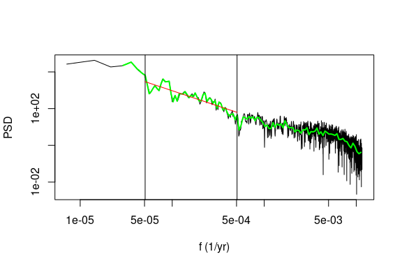

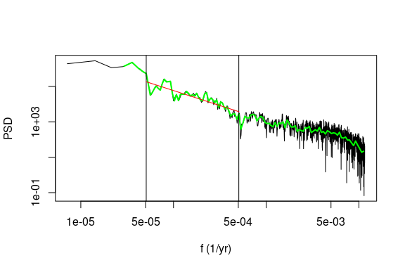

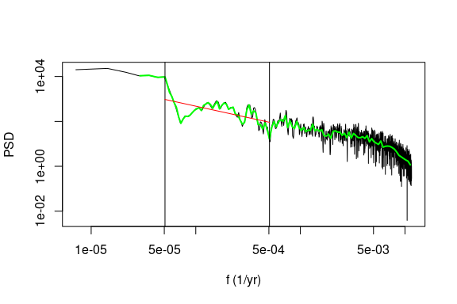

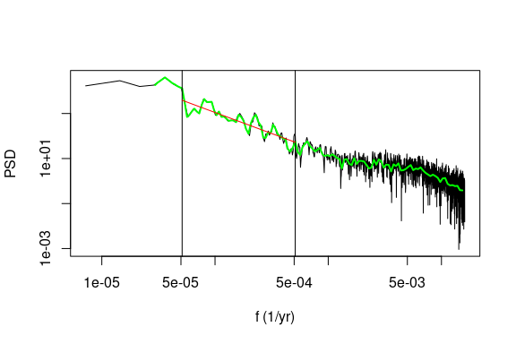

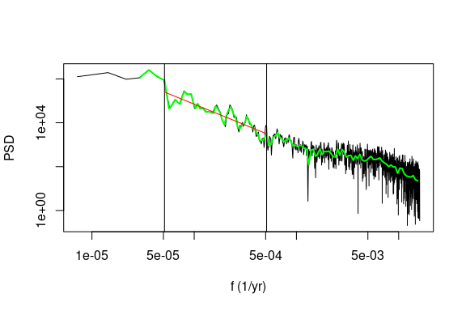

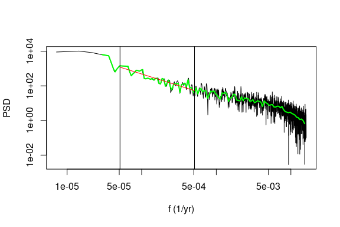

```r
head(testout$proxy_data,3)
```

```
#> [[1]]
#> [[1]]$EDCBag_18O
#> [[1]]$EDCBag_18O$slope
#> [1] -1.674163
#>
#> [[1]]$EDCBag_18O$slopesd
#> [1] 0.1373565
#>
#> [[1]]$EDCBag_18O$spec
#>   [1] 2.262784e+04 2.492051e+04 2.758162e+04 3.068611e+04 3.415667e+04
#>   [6] 2.587531e+04 1.955476e+04 1.456744e+04 1.210943e+04 9.366128e+03
#>  [11] 7.705027e+03 6.700457e+03 2.210901e+03 6.501706e+02 8.454578e+02
#>  [16] 1.293747e+03 1.775055e+03 1.230478e+03 9.623153e+02 2.316809e+03
#>  [21] 4.082459e+03 2.896532e+03 2.966097e+03 3.116159e+03 6.284524e+02
#>  [26] 2.364575e+02 5.189224e+02 2.575996e+02 6.438603e+02 6.364871e+02
```

[output cut: 376 more lines]